# Practical Machine Learning Course Project

Xin Zhang

January 24, 2015

## Summary

Using devices such as **Jawbone Up**, **Nike FuelBand**, and **Fitbit** it is now possible to collect a large amount of data about personal activity relatively inexpensively. These type of devices are part of the quantified self movement – a group of enthusiasts who take measurements about themselves regularly to improve their health, to find patterns in their behavior, or because they are tech geeks. One thing that people regularly do is quantify how much of a particular activity they do, but they rarely quantify how well they do it. In this project, your goal will be to use data from accelerometers on the belt, forearm, arm, and dumbell of 6 participants. They were asked to perform barbell lifts correctly and incorrectly in 5 different ways. More information is available from the website here: http://groupware.les.inf.puc-rio.br/har.

The objective of this project is to use the data available here:

https://d396qusza40orc.cloudfront.net/predmachlearn/pml-training.csv

to construct a machine learning algorithm to predict the manner in which the subject did the exercise. The report will describe the data, the model construction process, the model selection based on cross validation, and the expected error calculation.

Finally, I will also use the selected model to make prediction on the test data, which is available here:

https://d396qusza40orc.cloudfront.net/predmachlearn/pml-testing.csv

## Data

First step is to download and import the training and testing data from the above links.

```r
setwd('/Users/xinzhang/Documents/dataScience/MachineLearning')
download.file("https://d396qusza40orc.cloudfront.net/predmachlearn/pml-training.csv", "training.csv", method="curl")
download.file("https://d396qusza40orc.cloudfront.net/predmachlearn/pml-testing.csv", "testing.csv", method="curl")
data <- read.table("training.csv", sep=",", header=TRUE)
test <- read.table("testing.csv", sep=",", header=TRUE)
head(data[,1:10])
```

```
##   X user_name raw_timestamp_part_1 raw_timestamp_part_2   cvtd_timestamp
## 1 1  carlitos           1323084231               788290 05/12/2011 11:23
## 2 2  carlitos           1323084231               808298 05/12/2011 11:23
## 3 3  carlitos           1323084231               820366 05/12/2011 11:23
## 4 4  carlitos           1323084232               120339 05/12/2011 11:23
## 5 5  carlitos           1323084232               196328 05/12/2011 11:23
## 6 6  carlitos           1323084232               304277 05/12/2011 11:23
##   new_window num_window roll_belt pitch_belt yaw_belt
## 1         no         11      1.41       8.07    -94.4
## 2         no         11      1.41       8.07    -94.4
## 3         no         11      1.42       8.07    -94.4
## 4         no         12      1.48       8.05    -94.4
## 5         no         12      1.48       8.07    -94.4
## 6         no         12      1.45       8.06    -94.4
```

It could be seen that many columns have a lot of missing values, and hence they are read into R with a character value. The following code will change them into numeric values.

```r
num <- function(x) as.numeric(x)
data1 <- apply(data[,8:(ncol(data)-1)], 2, num)
head(data1[,1:10])
```

```
##      roll_belt pitch_belt yaw_belt total_accel_belt kurtosis_roll_belt
## [1,]      1.41       8.07    -94.4                3                 NA
## [2,]      1.41       8.07    -94.4                3                 NA
## [3,]      1.42       8.07    -94.4                3                 NA
## [4,]      1.48       8.05    -94.4                3                 NA
## [5,]      1.48       8.07    -94.4                3                 NA
## [6,]      1.45       8.06    -94.4                3                 NA
##      kurtosis_picth_belt kurtosis_yaw_belt skewness_roll_belt
## [1,]                  NA                NA                 NA
## [2,]                  NA                NA                 NA
## [3,]                  NA                NA                 NA
## [4,]                  NA                NA                 NA
## [5,]                  NA                NA                 NA
## [6,]                  NA                NA                 NA
##      skewness_roll_belt.1 skewness_yaw_belt
## [1,]                   NA                NA
## [2,]                   NA                NA
## [3,]                   NA                NA
## [4,]                   NA                NA
## [5,]                   NA                NA
## [6,]                   NA                NA
```

```r
finalData <- data.frame(data[,1:7], data1, data[ncol(data)])
dim(data)
```

```
## [1] 19622   160
```

```r
dim(finalData)
```

```
## [1] 19622   160
```

## Exploratory Analysis

I first separate the training and testing sample from the finalData I created above. Here I use 70% data as the training sample, while keep 30% data as the testing sample.

```r
library(caret)
```

```r
library(ggplot2)
set.seed(10011)
inTrain <- createDataPartition(y=finalData$classe, p=0.7, list=FALSE)
training <- finalData[inTrain, ]
testing <- finalData[-inTrain, ]
dim(training)
```

```
## [1] 13737   160
```

```r
dim(testing)
```

```
## [1] 5885  160
```

I then impute the missing values using the preProcess function in caret. The method of imputation is bagImpute. However, it is unfortunate that even after imputation, most of the predictors with missing values still contain a large portion of missing values. I finally decided to delete all the predictors containing a large portion of missing values.

```r
set.seed(500)
preObj <- preProcess(training[,8:(ncol(training)-1)], method="bagImpute")
preTrain <- predict(preObj, training[,8:(ncol(training)-1)])
preTest <- predict(preObj, testing[,8:(ncol(training)-1)])
include <- which(!apply(preTrain, 2, function(x) any(is.na(x))))
training1 <- data.frame(training[,1:7], preTrain[,include], training[ncol(training)])
testing1 <- data.frame(testing[,1:7], preTest[,include], testing[ncol(testing)])
```

A plot for selected features is given below. From the plot, it could be seen that constructing a linear model for classification would be difficult, since there barely linear trend between the predictors and the response in the data.

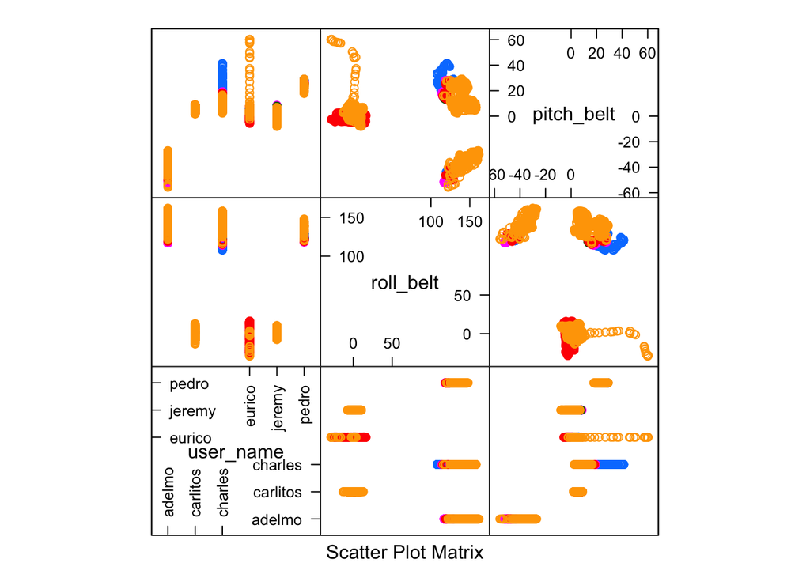

However, the user name factor is an important confounding factor in the dataset, which could be seen under the following density plot for several variables. The user name factor would affect the predictor levels.

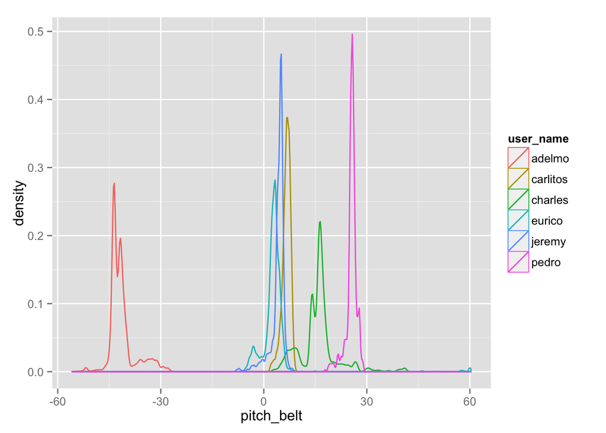

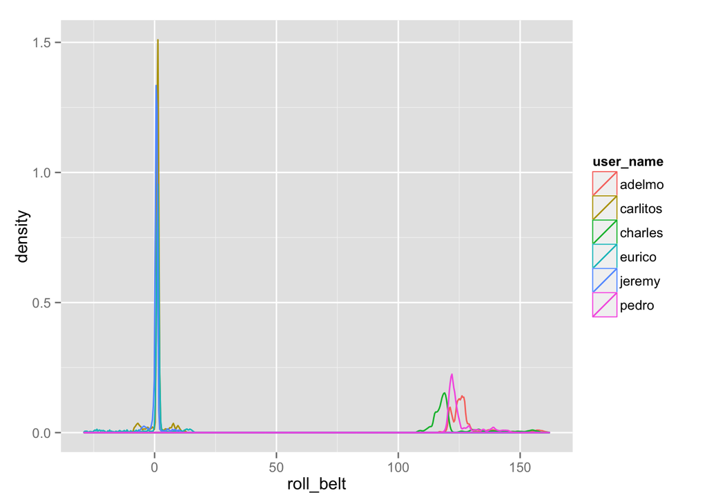

## Model Training

To construct a classification model using the above data for predict the manner of subjects’ exercise, the following issues are considered:

- Predictors

All predictors except for the number label (first column) in the dataset are used in the model. This is due to the reason that we do not want to lose any information.

- Preprocess

Due to the large missing values in some of the predictors, a bagged tree imputation is used. This method was already conducted in the exploratory analysis section. However, the missing value proportion is too large for the imputation to have a valid outcome. I finally decided to drop all variables with a large portion of missing values.

- Model

There are three potential models to select from namely, bagged tree, gradient boosting model, and random forest. All these models could deal with the non-linear pattern as the data suggested.

- Model selection

Repeated cross validation is used for model accuracy estimate of each model to tune the parameters in the model fitting. The final model selection would be based on the model accuracy on the testing sample.

### Gradient Boosting Model

```r
set.seed(888)
fitControl <- trainControl(method="repeatedcv", number=10, repeats=3)
boostFit <- train(classe~., data=training1[,-1], method="gbm", trControl = fitControl, verbose = FALSE)
boostFit
```

[output not shown]

### Bagged Tree

```r
set.seed(989)
fitControl <- trainControl(method="repeatedcv", number=10, repeats=3)
bagFit <- train(classe~., data=training1[,-1], method="treebag", trControl = fitControl, verbose = FALSE)
bagFit
```

```
## Bagged CART
##
## 13737 samples
##    58 predictors
##     5 classes: 'A', 'B', 'C', 'D', 'E'
##
## No pre-processing
## Resampling: Cross-Validated (10 fold, repeated 3 times)
##
## Summary of sample sizes: 12363, 12362, 12363, 12364, 12365, 12362, ...
##
## Resampling results
##
##   Accuracy  Kappa  Accuracy SD  Kappa SD
##   1         1      8e-04        0.001
##
##
```

### Random Forest

```r
set.seed(1989)
fitControl <- trainControl(method="repeatedcv", number=10, repeats=3)
rfFit <- train(classe~., data=training1[,-1], method="rf", trControl = fitControl, verbose = FALSE)
rfFit
```

[output not shown]

## Test Error Rate and Model Selection

The accuracy error rates on the testing sample could be estimated below.

### Gradient Boosting Model

```r
boostPred <- predict(boostFit, testing)
confusionMatrix(boostPred, testing$classe)
```

```
## Confusion Matrix and Statistics
##
##           Reference
## Prediction    A    B    C    D    E
##          A 1674    0    0    0    0
##          B    0 1133    3    0    0
##          C    0    5 1019    0    0
##          D    0    1    4  963    4
##          E    0    0    0    1 1078
##
## Overall Statistics
##
##                Accuracy : 0.997
##                  95% CI : (0.995, 0.998)
##     No Information Rate : 0.284
##     P-Value [Acc > NIR] : <2e-16
##
##                   Kappa : 0.996
##  Mcnemar's Test P-Value : NA
##
## Statistics by Class:
##
##                      Class: A Class: B Class: C Class: D Class: E
## Sensitivity             1.000    0.995    0.993    0.999    0.996
## Specificity             1.000    0.999    0.999    0.998    1.000
## Pos Pred Value          1.000    0.997    0.995    0.991    0.999
## Neg Pred Value          1.000    0.999    0.999    1.000    0.999
## Prevalence              0.284    0.194    0.174    0.164    0.184
## Detection Rate          0.284    0.193    0.173    0.164    0.183
## Detection Prevalence    0.284    0.193    0.174    0.165    0.183
## Balanced Accuracy       1.000    0.997    0.996    0.999    0.998
```

### Bagged Tree

```r
bagPred <- predict(bagFit, testing)
confusionMatrix(bagPred, testing$classe)
```

```
## Confusion Matrix and Statistics
##
##           Reference
## Prediction    A    B    C    D    E
##          A 1674    0    0    0    0
##          B    0 1135    0    0    0
##          C    0    4 1026    0    0
##          D    0    0    0  964    1
##          E    0    0    0    0 1081
##
## Overall Statistics
##
##                Accuracy : 0.999
##                  95% CI : (0.998, 1)
##     No Information Rate : 0.284
##     P-Value [Acc > NIR] : <2e-16
##
##                   Kappa : 0.999
##  Mcnemar's Test P-Value : NA
##
## Statistics by Class:
##
##                      Class: A Class: B Class: C Class: D Class: E
## Sensitivity             1.000    0.996    1.000    1.000    0.999
## Specificity             1.000    1.000    0.999    1.000    1.000
## Pos Pred Value          1.000    1.000    0.996    0.999    1.000
## Neg Pred Value          1.000    0.999    1.000    1.000    1.000
## Prevalence              0.284    0.194    0.174    0.164    0.184
## Detection Rate          0.284    0.193    0.174    0.164    0.184
## Detection Prevalence    0.284    0.193    0.175    0.164    0.184
## Balanced Accuracy       1.000    0.998    1.000    1.000    1.000
```

### Random Forest

```r
rfPred <- predict(rfFit, testing)
confusionMatrix(rfPred, testing$classe)
```

```
## Confusion Matrix and Statistics
##
##           Reference
## Prediction    A    B    C    D    E
##          A 1674    0    0    0    0
##          B    0 1136    2    0    0
##          C    0    3 1024    0    0
##          D    0    0    0  964    2
##          E    0    0    0    0 1080
##
## Overall Statistics
##
##                Accuracy : 0.999
##                  95% CI : (0.998, 1)
##     No Information Rate : 0.284
##     P-Value [Acc > NIR] : <2e-16
##
##                   Kappa : 0.998
##  Mcnemar's Test P-Value : NA
##
## Statistics by Class:
##
##                      Class: A Class: B Class: C Class: D Class: E
## Sensitivity             1.000    0.997    0.998    1.000    0.998
## Specificity             1.000    1.000    0.999    1.000    1.000
## Pos Pred Value          1.000    0.998    0.997    0.998    1.000
## Neg Pred Value          1.000    0.999    1.000    1.000    1.000
## Prevalence              0.284    0.194    0.174    0.164    0.184
## Detection Rate          0.284    0.193    0.174    0.164    0.184
## Detection Prevalence    0.284    0.193    0.175    0.164    0.184
## Balanced Accuracy       1.000    0.998    0.999    1.000    0.999
```

## Final Prediction on Test Sample

The final prediction on the test sample is as follows.

```r
prediction <- predict(rfFit, test)
prediction
```

```
##  [1] B A B A A E D B A A B C B A E E A B B B
## Levels: A B C D E
```